P3_CosMx_v2 · steps 01–24 · internal

# Manuscript readiness review

What the project has established, the gaps that remain, a draft abstract, and a figure list with legends. Composite classic Hodgkin / follicular lymphoma node (IB1) and the same patient's follicular recurrence (RB1), CosMx 6K.

**Revised 8 September 2026**, superseding the 1 September version · every number is quoted from an existing report or result table, with the source named inline; nothing here is newly computed · plain-text companion: `MANUSCRIPT_PLAN.md`

## Revision notice — what changed since 1 September

Four gaps are closed and are no longer listed

**Gap numbering is preserved**, so the gaps that remain keep their original identifiers: **G2, G3, G6 and G8**. The closed four are summarised here and reported in full in `output/24_summary/step22_24_gap_closure.html` and `output/21_summary/step21_interface.html`.

| Gap | Closed by | Verdict |
| --- | --- | --- |
| **G1** — step-19 labels terminal | steps 24 + 24b | **R9 CORRECTED.** The two callers agree on 70.2% of cells; step 16's "RB1 sits at chance" was the caller's silence, not RB1's architecture. |
| **G4** — no ligand–receptor analysis | step 22 | Co-expression in proximity is measurable and **small** (1.01–1.18×). Only *CXCL13*–*CXCR5* is distance-robust; the largest value in the table is leakage-shaped. |
| **G5** — no copy-number inference | step 23 | **9p24.1 dosage NOT obtained.** The no-Hodgkin control fires and the signal is not confined to one lineage. |
| **G7** — FL/Hodgkin interface | step 21 | A **bounded null** in expression and composition; lesion arrangement **unresolved**, not negative. |

One established result changed, and it propagates

## 1. What the project has established

### 1.1 Results that survive their own scrutiny

[output not shown]

### 1.3 Closed negatives that constrain the paper

Per-cell HRS/CD30 calling. Light-chain regionalisation of RB1. Cross-sample neighbourhood matching (2 of 89 bins). The difference-in-differences (0 of 30, MDE 1.8–2.5 fold). Transcript-level PD-1/PD-L1 proximity (**NOT DELIVERED**). Segmentation fragmentation of HRS. Cluster-based T-cell subsetting. Compartment-restricted cell typing. HCA tonsil label transfer. **New:** 9p24.1 copy-number inference; distance-to-hotspot as a field-exposure axis; the FL-response-to-field interaction (bounded null).

## 2. Gaps that remain

Four gaps are closed (see the revision notice) and are not repeated. **Numbering is preserved** so cross-references to earlier drafts still resolve.

### G2 — There is no morphological or protein confirmation of anything blocking · top priority

Five morphology channels are on the slide and `output/15_imagej/` holds a reviewable export (overview, 34 full-resolution crops, ROIs for 29 hotspots and the FL neighbourhoods). **No reviewed verdict is recorded anywhere in `output/`.**

Why this is first among equals

The central claim is a chemokine field radiating from focal peaks that have never been shown to contain Reed–Sternberg cells. As it stands the hotspots are *defined* by a chemokine measurement and *validated* by the same chemokine measurement.

- **No pathologist read of the hotspot ROIs.** The export exists for this and was never used.
- **No RB1 ImageJ export** — an image-side positive with no image-side negative control.
- **No orthogonal assay.** CD30 (and PD-L1) IHC on the block is outside this dataset but is the obvious cheap anchor, and it does not have the panel's dynamic-range problem.

What is new since 1 September

Step 22's snapshots (`output/22_lr/matched/snapshots/figures/`) prove the rendering pipeline works end to end on the real OME-TIFFs — tight crops with segmentation boundaries and transcript positions on 5-channel morphology. The same machinery would render the hotspot ROIs for review, so **the remaining cost of G2 is a pathologist's time, not engineering**.

### G3 — The 4.07× far-field IB1:RB1 residual is unattributed blocks R1's framing

Untried: a negprobe-anchored technical-offset estimate; the morphology channels (diffuse HRS cells are large and CD45-dim and might be visible without transcript calling); an FOV-level offset model fit on housekeeping genes.

### G6 — RB1 is analytically under-served medium

1.4M cells that mostly serve as a null — and step 24b makes this sharper, because RB1 turns out to have real architecture that the old labels could not see.

- **Step 14 never ran on RB1** — `output/14_lightchain_in_out/` contains `IB1/` only.
- The **12,394 light-chain-evaluable RB1 cells with no neighbourhood** have never been examined. If they are spatially clustered they are RB1's only internal reference. (Note the corrected denominator: 466,764 RB1 cells were light-chain-evaluable, not 1.29M — the older "the clone *is* the node" phrasing overstated it ~3×.)
- No ImageJ export (see G2).

### G8 — Composition is reported without uncertainty closed · step 25a

**Closed.** `25_script_composition_fov.R` computes the per-FOV share of every label among high-confidence cells and reports its spread; `output/25_figures/composition_fov_summary.csv` and Figure 1d carry it.

And it changes how one headline may be phrased

IB1's composition is far less stable across the section than RB1's. Its two largest fractions have almost completely overlapping interquartile ranges — myeloid 17.7–34.1% against B cell 17.5–35.2% — so **"IB1 is myeloid-dominant" is not supportable**, though "IB1 is 23.6% B against RB1's 71.4%" is (RB1's B IQR is 66.1–77.7%, disjoint from IB1's). The pooled myeloid estimate also sits 4.4 points above the FOV median, so a few dense fields carry it.

### Lower priority

- **No external reference anchor.** A published cHL or FL spatial/scRNA dataset would independently support the DC (R4) and Tfh (R10) calls.
- **Neutrophil rests on one gene** (CSF3R). Fold it into `unresolved`.
- **Treg has no independent validator on this panel.** The paper should avoid the word.
- **No point-pattern statistics** (cross-K, pair correlation). The density-stratified permutation is arguably better, but a reviewer may ask.
- **Bin-size sensitivity** is swept for hotspots but not for the architecture axis that R9–R12 rest on.
- **The `arch` axis means different biology in the two samples.**
- new **Minor-lineage identity is a coin flip between callers** — NK 32.1% and plasma cell 37.5% agreement. Any claim resting on NK or PC identity needs both callers to agree, or needs dropping.

### Out of reach — state as limitations, do not chase

n = 1 patient, two sections; the between-section offset is not estimable from two sections. Per-cell HRS calling on this panel. Cross-sample regional contrasts for the offset-affected genes. Spatial engagement of the PD-1 axis. Per-cell leakage correction. 9p24.1 copy number from a 6K targeted panel.

## 3. Proposed abstract

Framing decision, unchanged

**(A)** the biology — a composite node where the Hodgkin component projects a bounded chemokine and checkpoint-ligand field over adjacent tissue — is the stronger paper, with the methodological discipline visible in its limitations and supplement.

**Composite lymphoma places two diseases in one microenvironment.** We profiled a lymph node containing classic Hodgkin lymphoma (cHL) together with follicular lymphoma (FL), and the same patient's subsequent FL recurrence, by single-molecule spatial transcriptomics (CosMx 6K; 4.4 million segmented cells, two sections, one patient).

Reed–Sternberg cells were not identifiable per cell on this panel — *TNFRSF8* reaches six counts with 78% singletons, and the Hodgkin-free recurrence was 6.27% CD30-positive against the composite node's 7.01% — so we replaced per-cell calling with a regional readout. *CCL17*/*CCL22* defined 80 focal hotspots in the composite node and none in the recurrence at an identical threshold and a symmetric quality tier. The elevation is a spatially decaying field rather than a section-level offset: chemokine falls 2.71-fold [1.95–3.91] between 100–400 µm and beyond 1600 µm from a peak, against 1.20-fold [1.14–1.26] in the recurrence, with most of the decay spent by 400–800 µm, and it persists within every lineage. Hotspots are dendritic-cell rather than macrophage territory and carry *BATF3*, *CD40* and *IL6*, with *BATF3* enrichment highest farthest from any dendritic cell, excluding transcript spillover. The field is accompanied by a *CCR4* gradient roughly 3.5-fold steeper inside FL foci than tissue-wide, with *FOXP3* flat — chemoattraction without a regulatory T-cell signature. Hotspots carry elevated *CD274* and *PDCD1LG2* with *PDCD1* and interferon-γ response flat: ligand-side activation, the pattern 9p24.1 copy gain predicts, though a direct dosage test on this panel could not confirm gain. The recurrence independently reproduced the canonical follicular PD-1 pattern of FL. Under a composition- and density-preserving permutation both nodes departed from random cellular arrangement, about twice as strongly in the composite node.

Conditioned on cell type, no gene distinguished FL foci from background, and FL tissue's response to the Hodgkin field was indistinguishable from ordinary tissue's. The Hodgkin component therefore remodels the *composition and milieu* of neighbouring tissue over several hundred micrometres without altering the transcriptional state of individual bystander cells. Findings are descriptive (n = 1).

**~305 words. Two sentences changed from the 1 September draft**, both because later work corrected them: the architecture sentence no longer says the recurrence had *lost* organisation (step 24b), and the 9p24.1 clause no longer asserts the mechanism (step 23).

#### Title options

1. A Hodgkin chemokine field with a measured extent remodels adjacent follicular lymphoma in a composite lymph node
2. Ligand-side checkpoint activation within a spatially bounded Hodgkin chemokine field
3. Composition, not cell state: what a Hodgkin lesion does to the tissue around it

## 4. Figure list with legends

Status — have exists as a PNG; make data exists, figure does not; blocked needs work not yet done, with the gap named.

### Figure 1 · The case, the tissue, and the analytical substrate

- **(a)** Whole-section 5-channel morphology, both samples, with ROI overlays blocked · G2
- **(b)** `19_celltypes/figures/celltype_spatial.png` have
- **(c)** `19_celltypes/figures/qc_spatial.png` have
- **(d)** `output/25_figures/fig_25_1d_composition_fov.png` have — G8 closed by `25_script_composition_fov.R`

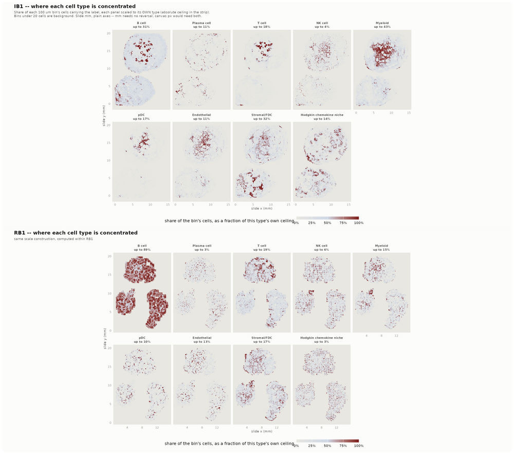

output/19_celltypes/figures/celltype_spatial.png

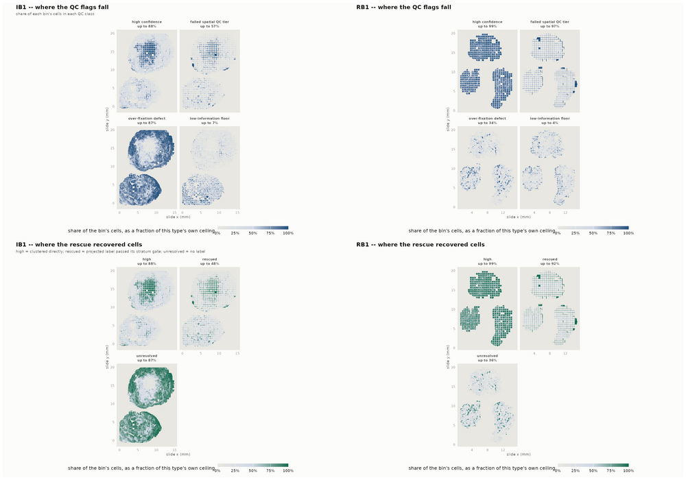

output/19_celltypes/figures/qc_spatial.png

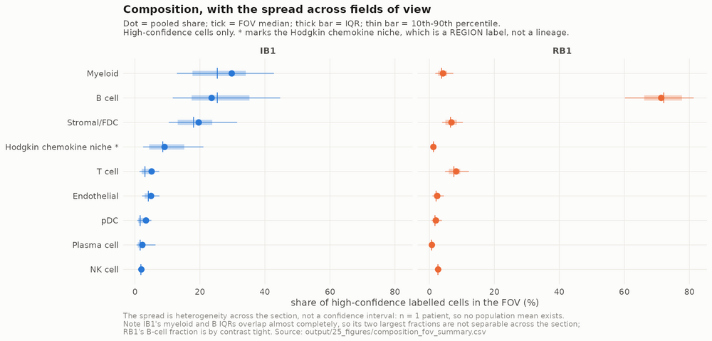

output/25_figures/fig_25_1d_composition_fov.png

Previews are downscaled; the paths above each caption are the full-resolution originals.

**Figure 1. A composite Hodgkin/follicular lymphoma node and its follicular recurrence.** (a) Whole-section morphology; cyan outlines mark *CCL17*+*CCL22* hotspots, orange the light-chain-defined FL neighbourhoods. (b) Cell-type assignment across both sections, from a merged clustering of quality-passing, non-defect cells with per-cell marker argmax carried as a separate column; colour scales are per panel and not comparable between types. (c) Two distinct technical geographies: IB1's over-fixation defect forms a peripheral rim while quality-tier failures form an FOV grid. Cells failing either are excluded per cell before clustering. Note the defect is spatially confounded with the regions analysed later — 0.33 defect fraction in FL bins, 0.45 in background, 0.59 in hotspots — and is carried as a covariate throughout. (d) Composition by sample among high-confidence cells; bars show the FOV-level interquartile range. RB1 is 71.4% B cells against IB1's 23.6%.

### Figure 2 · Cell identity: two callers, held-out validation

- **(a)** `19_celltypes/figures/celltype_umap_high.png` have
- **(b)** `19_celltypes/figures/marker_heatmap.png` have
- **(c)** `19_celltypes/figures/composition_figure.png` have
- **(d)** `output/25_figures/fig_25_2d_caller_agreement.png` have

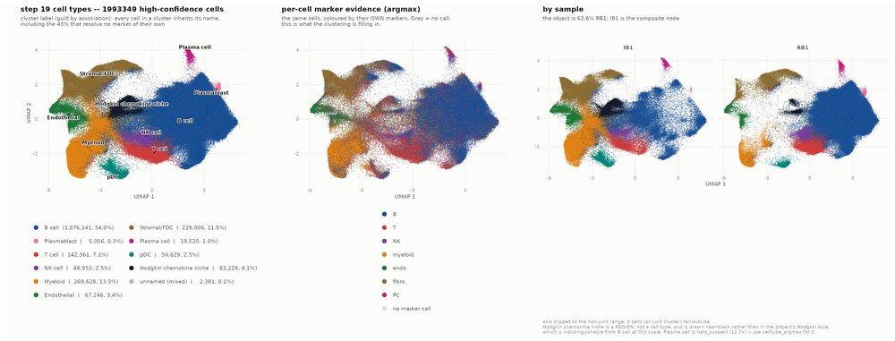

output/19_celltypes/figures/celltype_umap_high.png

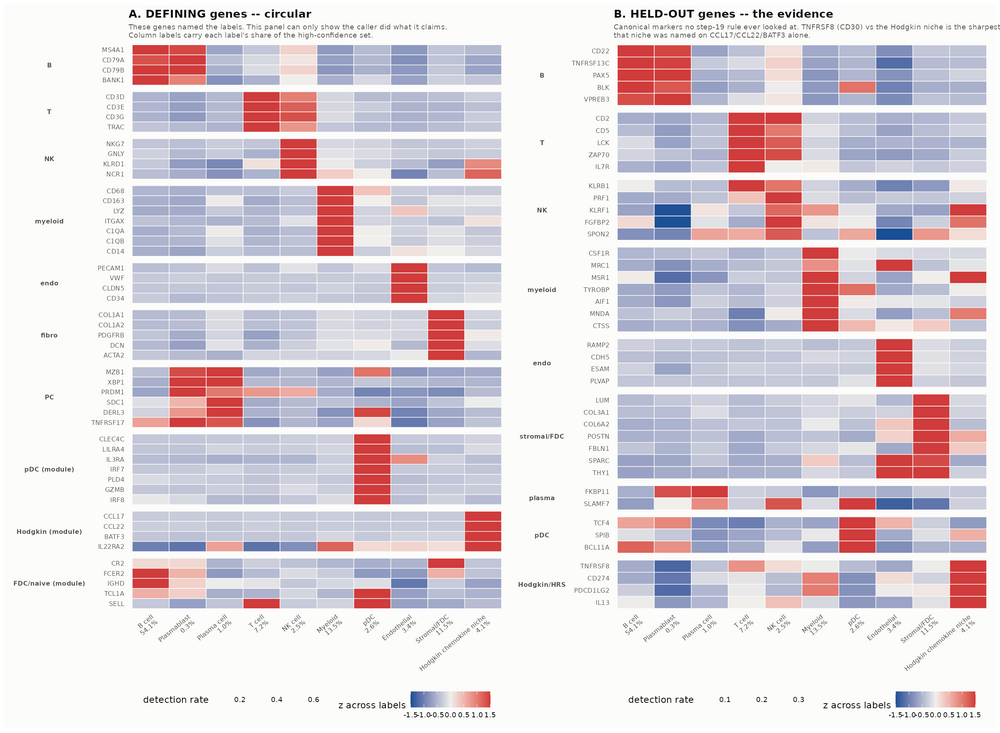

output/19_celltypes/figures/marker_heatmap.png

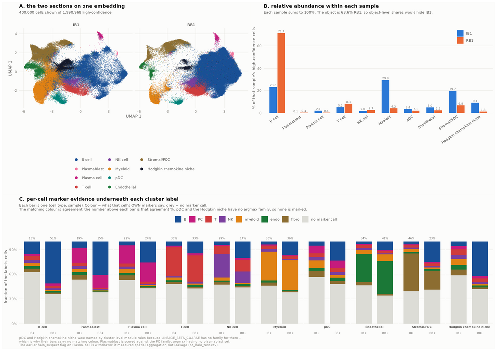

output/19_celltypes/figures/composition_figure.png

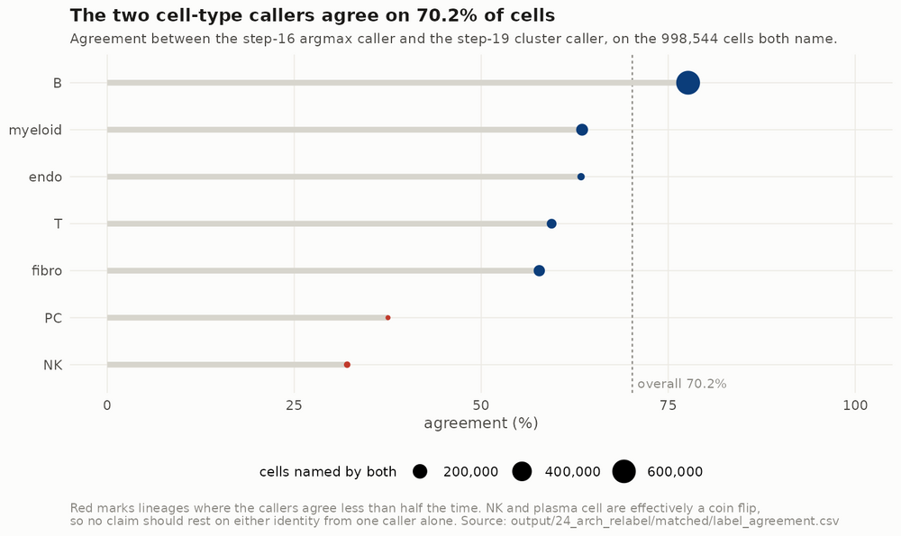

output/25_figures/fig_25_2d_caller_agreement.png

Previews are downscaled; the paths above each caption are the full-resolution originals.

### Figure 3 · A Hodgkin-specific chemokine field with a measured extent

- **(a)** `fig_11_niche_map_IB1.png` + `fig_16_regions_*.png` have
- **(b)** `17_pd1/matched/figures/fig_17_field_extent.png` have
- **(c)** `fig_11_confound_within_lineage.png` have
- **(d)** `fig_11_hotspot_myeloid_vs_dc.png` have
- **(e)** Annotated morphology crop of a hotspot ROI blocked · G2

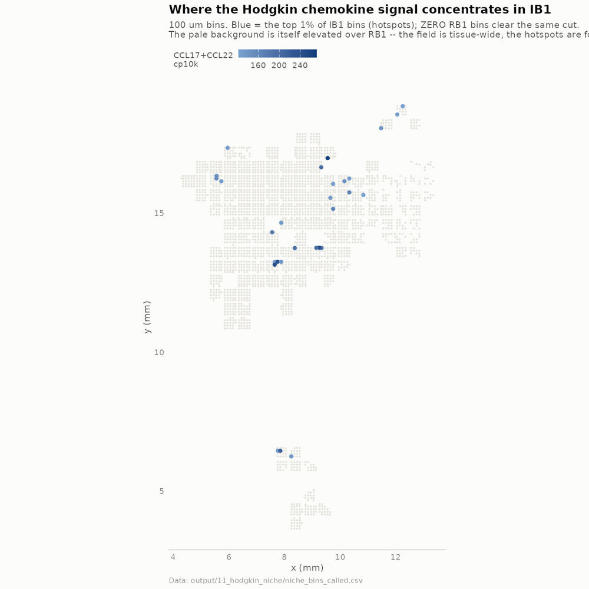

output/11_hodgkin_niche/figures/fig_11_niche_map_IB1.png

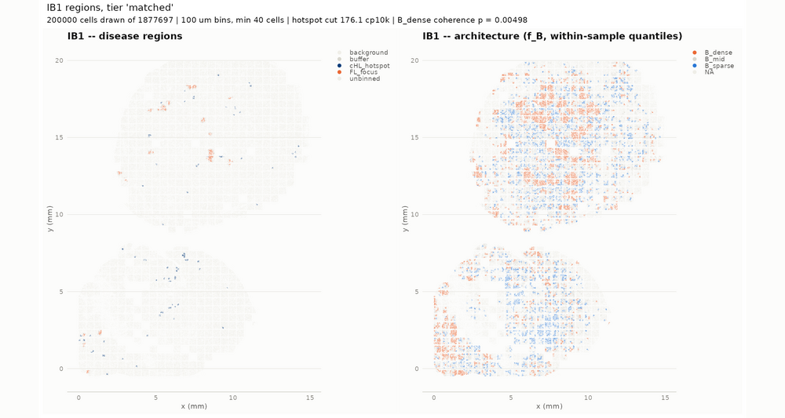

output/16_regions/matched/figures/fig_16_regions_IB1.png

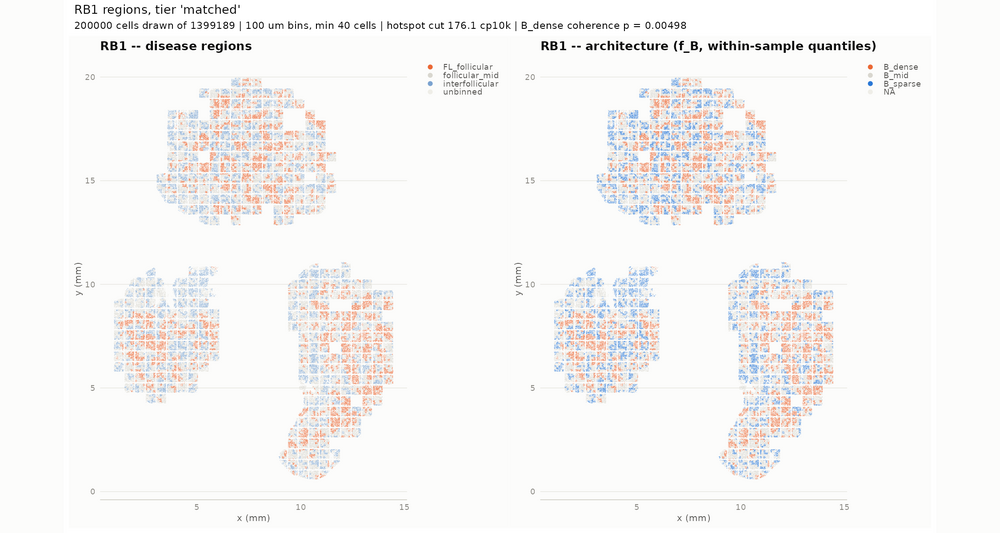

output/16_regions/matched/figures/fig_16_regions_RB1.png

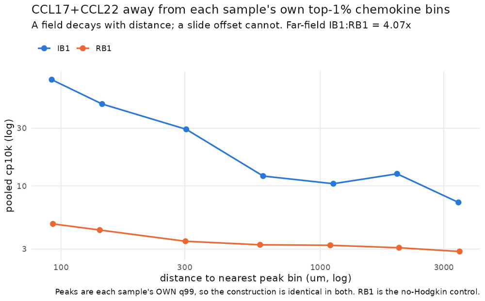

output/17_pd1/matched/figures/fig_17_field_extent.png

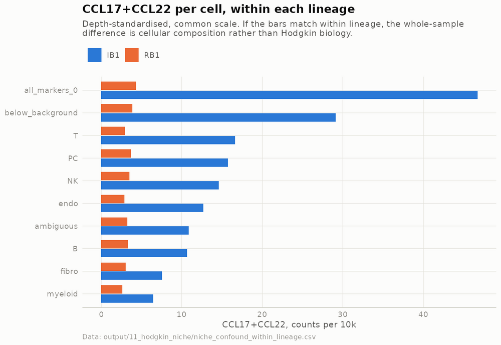

output/11_hodgkin_niche/figures/fig_11_confound_within_lineage.png

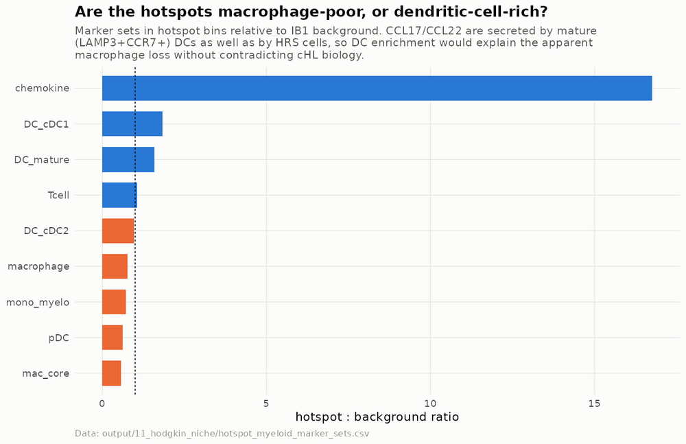

output/11_hodgkin_niche/figures/fig_11_hotspot_myeloid_vs_dc.png

Previews are downscaled; the paths above each caption are the full-resolution originals.

**Figure 3. The Hodgkin component projects a chemokine field that decays over 400–800 µm.** (a) *CCL17*+*CCL22* per 100 µm bin; 80 hotspots in the composite node, **none** in the recurrence at the same threshold. Sequential scale clamped to the 5th–99th percentile. (b) Decay from each sample's own top-1% bins, so the construction is identical in both and the recurrence is a no-Hodgkin control: IB1 falls 2.71-fold [1.95, 3.91], RB1 1.20-fold [1.14, 1.26], ratio 2.27-fold [1.62, 3.25] on an FOV cluster bootstrap. Spearman's rho does *not* discriminate (−0.180 vs −0.095) — the amplitude of the decay is the informative quantity, not its monotonicity. Beyond 1600 µm a flat 4.07-fold residual remains, unattributed. (c) The elevation holds within every lineage. (d) Hotspots are dendritic-cell rather than macrophage territory: cDC1 1.83-fold, mature DC 1.59-fold, macrophage 0.77-fold. (e) Morphology at a representative hotspot.

### Figure 4 · What the field does to the tissue around it

- **(a)** `16_gradient/matched/figures/fig_16_field_gradient.png` have
- **(b)** `output/25_figures/fig_25_4b_batf3_vs_cdc_distance.png` have
- **(c)** `output/25_figures/fig_25_4c_ccr4_axis.png` have
- **(d)** `16_rings/matched/figures/fig_16_fl_edge_rings.png` have

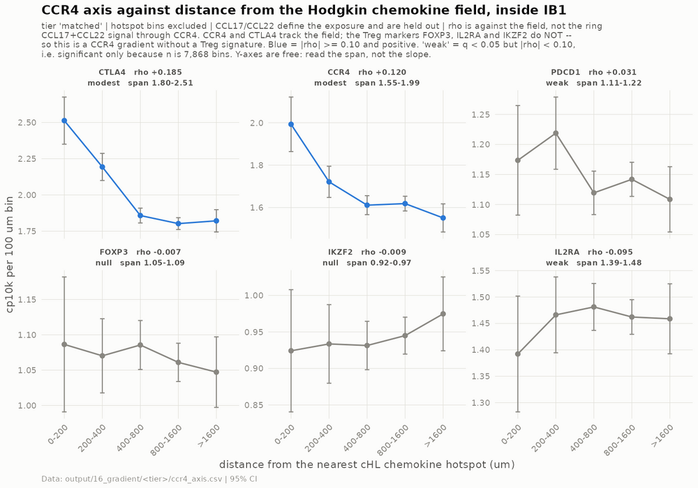

output/16_gradient/matched/figures/fig_16_field_gradient.png

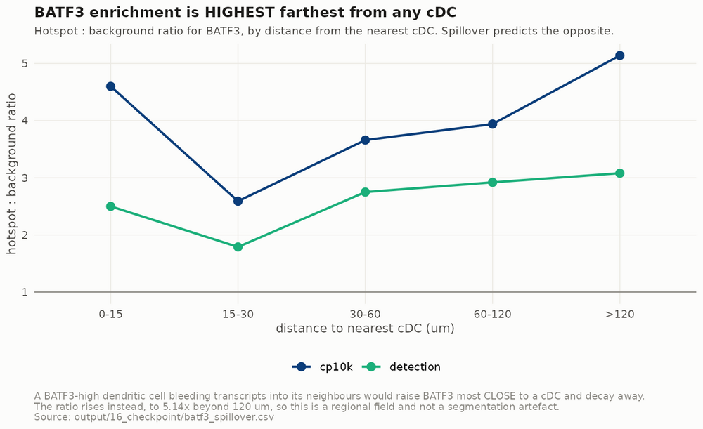

output/25_figures/fig_25_4b_batf3_vs_cdc_distance.png

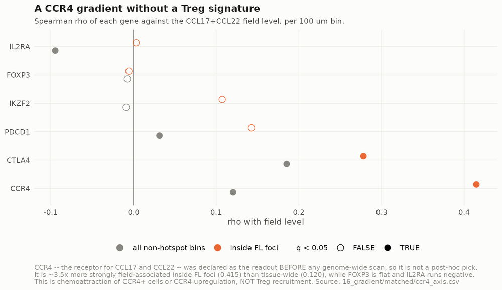

output/25_figures/fig_25_4c_ccr4_axis.png

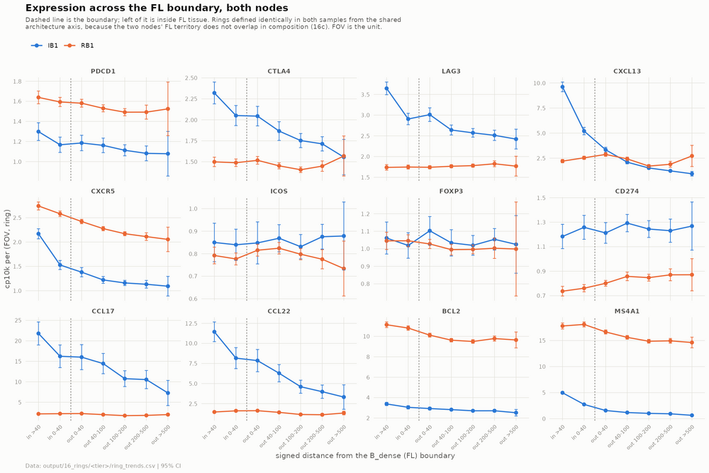

output/16_rings/matched/figures/fig_16_fl_edge_rings.png

Previews are downscaled; the paths above each caption are the full-resolution originals.

**Figure 4. The field is transcriptionally coherent and reaches into the FL tissue.** (a) Genome-wide association with the field axis independently recovers the Hodgkin programme: *BATF3* 0.555, *CD40* 0.389, *IL6* 0.335 lead the positive list, the negative list being normal T-zone architecture. (b) *BATF3* enrichment is *highest* farthest from any cDC (5.14-fold beyond 120 µm), the opposite of what spillover predicts. (c) *CCR4* was declared as the readout before any genome-wide scan; its association with the field is ~3.5-fold stronger inside FL foci (rho 0.415, q = 1.4e-4) than tissue-wide, while *FOXP3* is flat and *IL2RA* negative — a *CCR4* gradient without a regulatory T-cell signature. Note this is a **regional** association: at the level of individual cell pairs, *CCL17*/*CCL22*–*CCR4* co-expression in proximity is *below* chance inside the FL foci (Figure 7). (d) Across the FL boundary the two nodes diverge: the recurrence grades its germinal-centre programme, the composite node grades the chemokines instead.

### Figure 5 · Checkpoint: ligand-side in the Hodgkin component, receptor-side in the FL

- **(a)** `output/25_figures/fig_25_5a_module_contrasts.png` have — cross-sample facets are marked as bounded by the design
- **(b)** `output/25_figures/fig_25_5b_forest_ib1_hotspot.png` have
- **(c)** `output/25_figures/fig_25_5c_forest_rb1_follicular.png` have
- **(d)** `output/25_figures/fig_25_5d_did_vs_reference.png` have
- **(e)** `output/25_figures/fig_25_5e_9p24_dosage.png` have

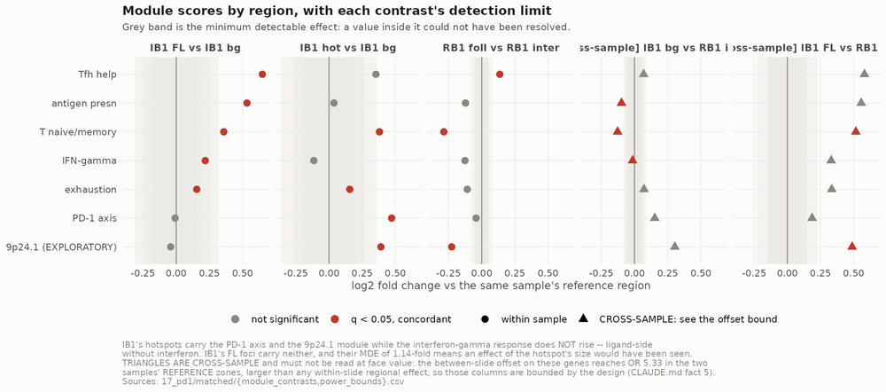

output/25_figures/fig_25_5a_module_contrasts.png

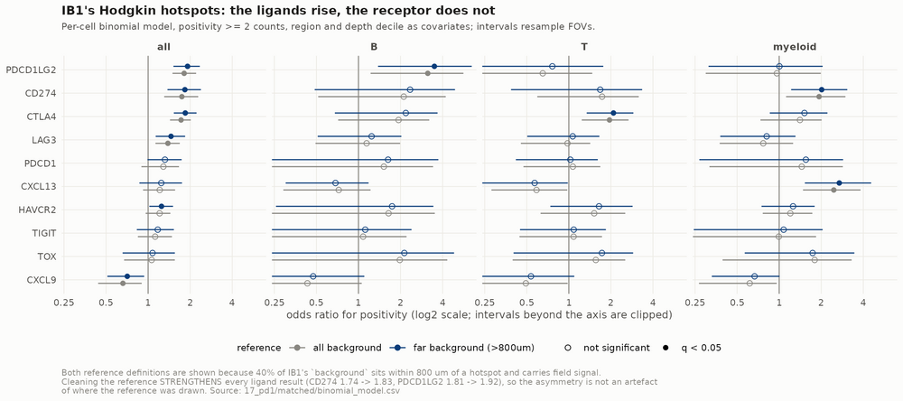

output/25_figures/fig_25_5b_forest_ib1_hotspot.png

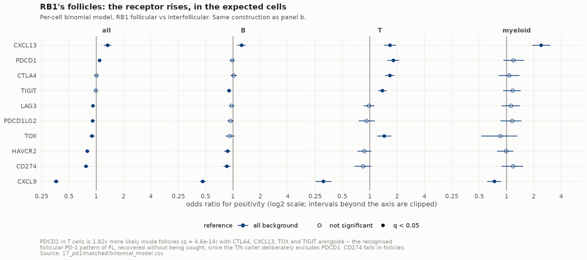

output/25_figures/fig_25_5c_forest_rb1_follicular.png

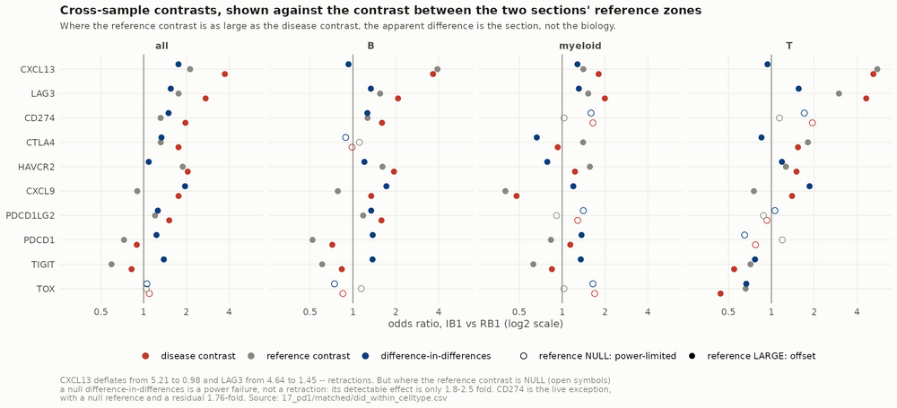

output/25_figures/fig_25_5d_did_vs_reference.png

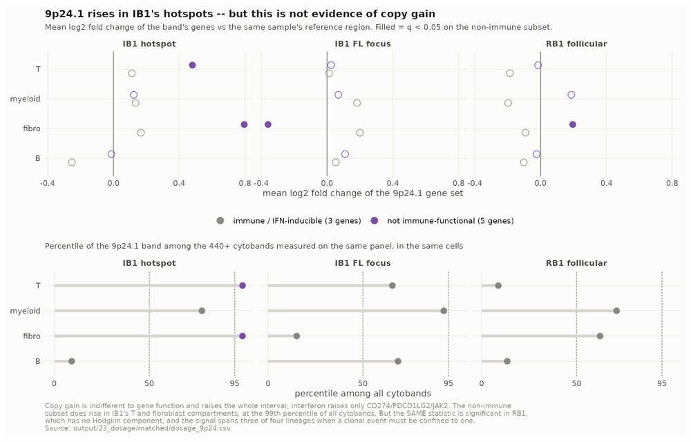

output/25_figures/fig_25_5e_9p24_dosage.png

Previews are downscaled; the paths above each caption are the full-resolution originals.

**Figure 5. The two lesions engage the PD-1 axis from opposite ends, and the mechanism is not established.** Positivity is ≥ 2 counts, modelled per cell with region and depth decile as covariates; intervals from resampling fields of view. IB1's reference is `background` restricted to >800 µm from any hotspot. (a) The hotspots carry the PD-1 axis (+0.472 log2, q = 2.1e-5) and the 9p24.1 module (+0.391, q = 2.6e-5) while the interferon-γ response does *not* rise. (b) Per cell the elevation is ligand-side only: *CD274* OR 1.83, *PDCD1LG2* 1.92, *PDCD1* 1.32 (ns). (c) The recurrence shows the reciprocal pattern in the expected cells: *PDCD1* in T cells 1.82-fold more likely inside follicles (q = 4.6e-14), recovered without being sought. (d) Cross-sample contrasts shown beside the two sections' *reference* contrast: where the reference is large the apparent difference is the section (*CXCL13* 5.21 → 0.98). *CD274* is the exception — reference null, residual 1.76-fold, unresolved rather than refuted. (e) **The dosage test does not support 9p24.1 gain.** The band scores in the 99th percentile of 440+ cytobands in IB1's hotspots with non-immune 9p24.1 genes rising too — but the same statistic fires in the no-Hodgkin recurrence (q = 0.039) and the signal spans three of four lineages, when a clonal copy event must be confined to one. The module stays exploratory.

### Figure 6 · Architecture: both nodes are organised, the composite node more strongly revised

- **(a)** `16_cooccur/matched/figures/fig_16_cooccurrence.png` have
- **(b)** `output/25_figures/fig_25_6b_architecture_both_callers.png` have
- **(c)** `16_composition/matched/figures/fig_16_composition_did.png` have
- **(d)** `16_tfh_views/matched/tfh_*.png` have

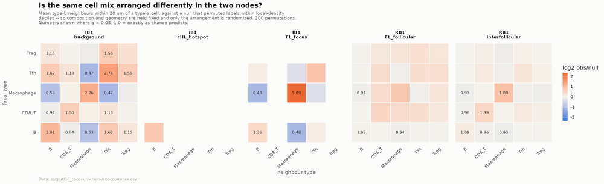

output/16_cooccur/matched/figures/fig_16_cooccurrence.png

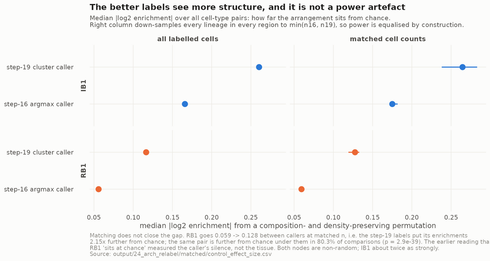

output/25_figures/fig_25_6b_architecture_both_callers.png

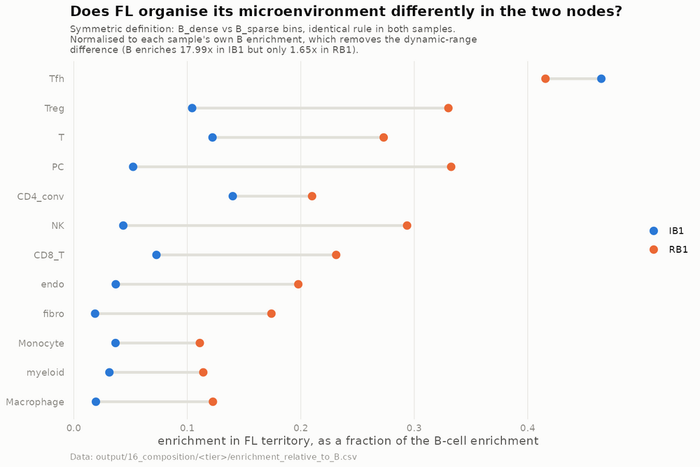

output/16_composition/matched/figures/fig_16_composition_did.png

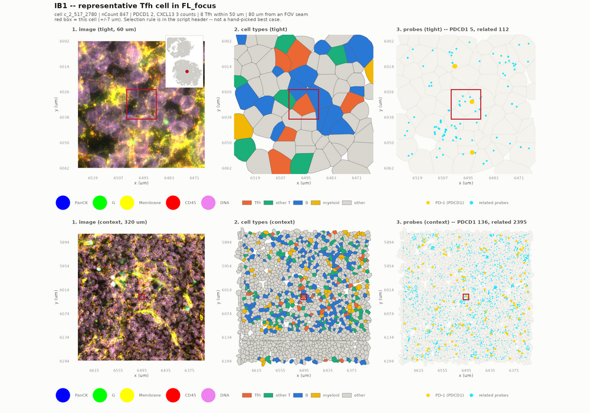

output/16_tfh_views/matched/tfh_IB1_FL_focus_2_517_2780.png

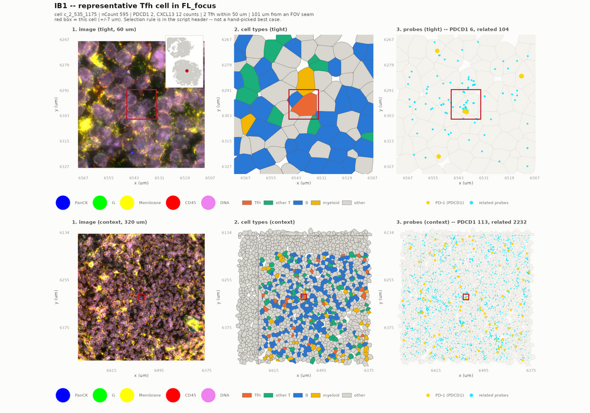

output/16_tfh_views/matched/tfh_IB1_FL_focus_2_535_1175.png

Previews are downscaled; the paths above each caption are the full-resolution originals.

**Figure 6. Composition held fixed, the two nodes are arranged differently — but neither is random.** The null permutes cell-type labels within local-density deciles, so composition and geometry are fixed and only the assignment of types to positions is randomised. (a) Pairwise co-occurrence enrichment by sample and region: in IB1's background Tfh self-aggregate at 2.74-fold chance, preferentially neighbour B cells at 1.62-fold and avoid macrophages at 0.47-fold. (b) **A correction.** An earlier analysis reported the recurrence as sitting at chance throughout. Repeating it under an improved cell-type caller, with every lineage down-sampled to matched cell counts so power is equalised, the recurrence's enrichments sit **2.15-fold further from chance** than the old labels showed, and the same pair is further from chance under the better labels in 80.3% of comparisons (p = 2.9e-39). Both nodes are non-randomly arranged; the composite node about twice as strongly (median |log2 enrichment| 0.265 vs 0.128). The earlier reading measured the caller's silence, not the tissue. (c) Tfh is nonetheless the only population that follows the FL B cells at a comparable rate in both nodes. (d) Registered morphology at representative Tfh-rich regions.

### Figure 7 · What a small proximity enrichment actually looks like new

- **(a–b)** `fig_22_snap_CXCL13CXCR5_{cherry,repr}.png` have
- **(c)** `fig_22_snap_PDCD1LG2PDCD1_repr.png` have
- **(d)** `output/25_figures/fig_25_7d_lr_distance_profile.png` have — built on `enrich_fov`, the quantity step 22 reports

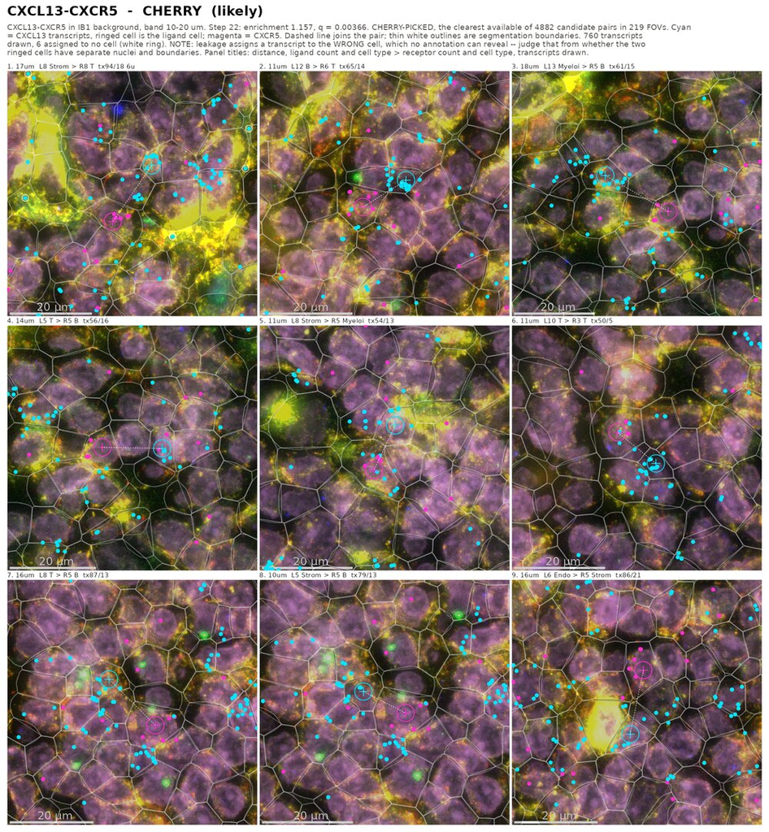

output/22_lr/matched/snapshots/figures/fig_22_snap_CXCL13CXCR5_cherry.png

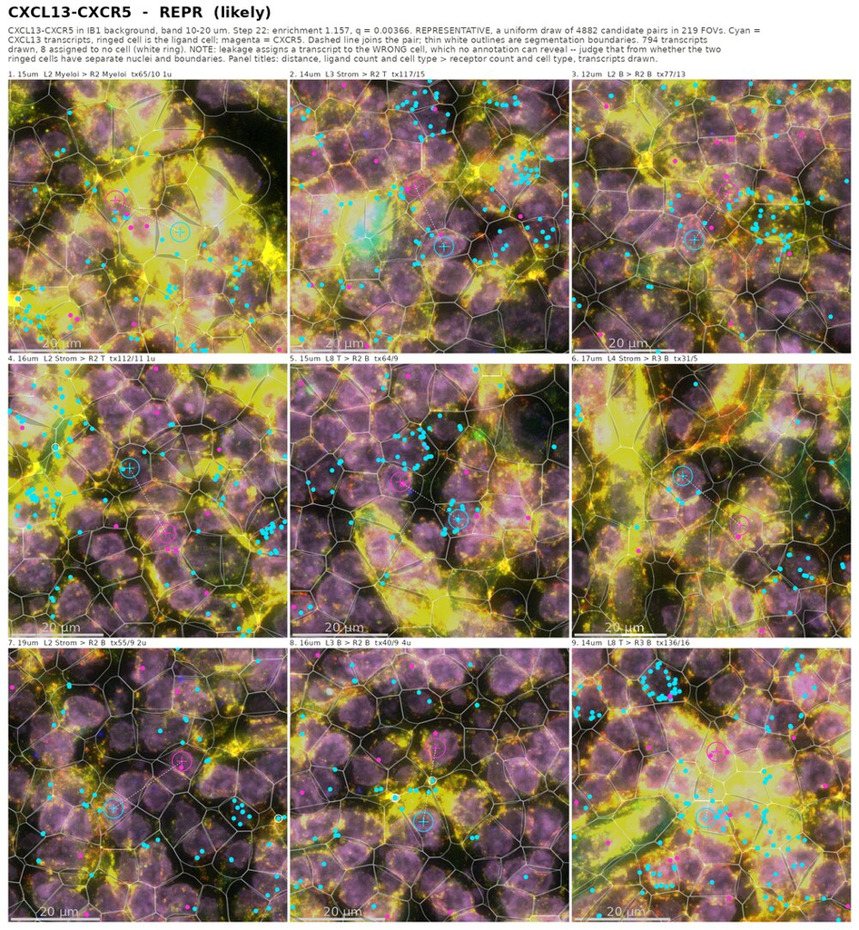

output/22_lr/matched/snapshots/figures/fig_22_snap_CXCL13CXCR5_repr.png

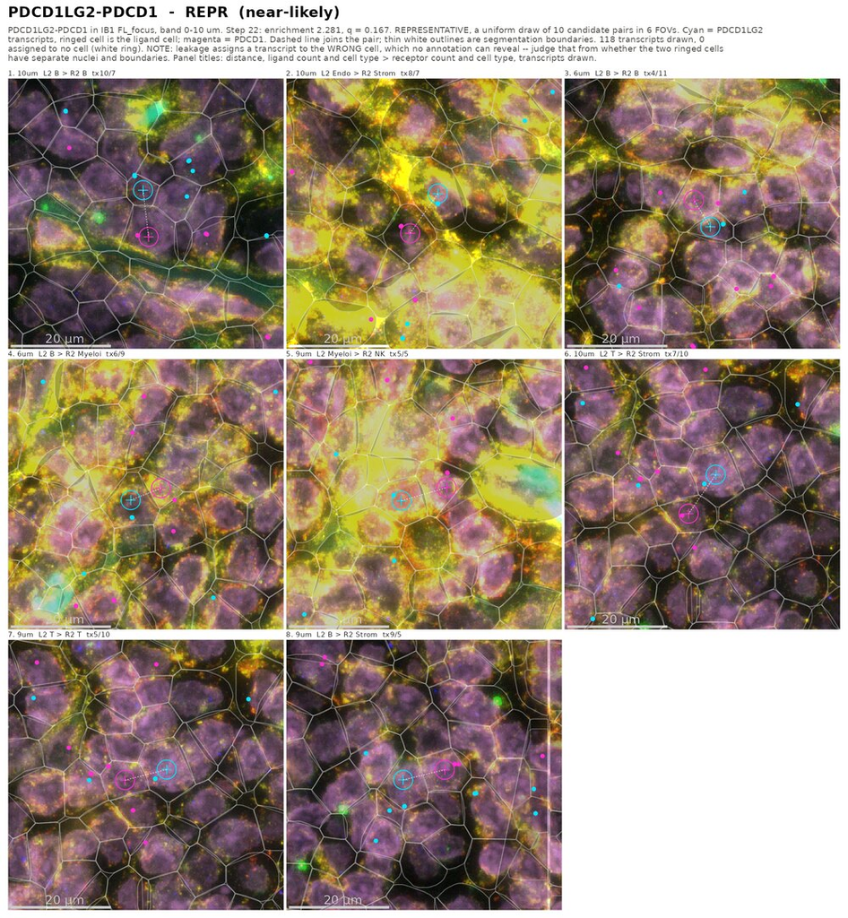

output/22_lr/matched/snapshots/figures/fig_22_snap_PDCD1LG2PDCD1_repr.png

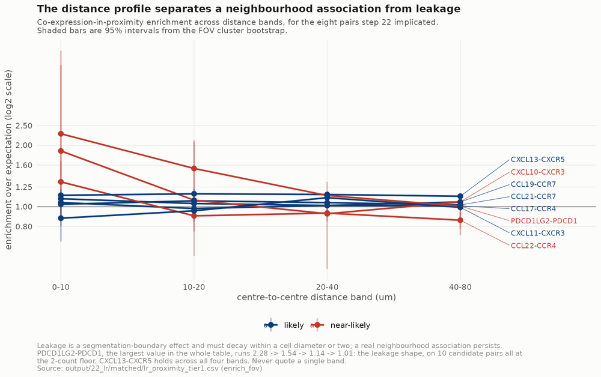

output/25_figures/fig_25_7d_lr_distance_profile.png

Previews are downscaled; the paths above each caption are the full-resolution originals.